# `R3-L3S1` **Le genre**

Lola **LUBIN** Alexis **VIALATTE

MAJ :** `16-12-2020`

[figure not shown]

Le genre dans la licence d’Économie à Tours.

# Support :

## La mise en place :

Nous allons nous servir de ces `packages` :

```r
library( readr )# pour l'import de la base de données,
library( DT )# pour la base de données,
library( knitr )# pour les tableaux,
library( kableExtra )# pour les tableaux,
library( gtsummary )# pour les tableaux,
library( printr )# pour les tableaux à trois variables,
library( modelsummary )# pour les tableaux automatiques,
library( dplyr )# pour la syntaxe des tableaux,
library( ggplot2 )# pour les figures,
library( ggridges )# pour les figures,
library( ggpubr )# pour les figures,

library( tidyr )# pour `drop_na` notamment,
library( forcats )# pour les levels notamment,
```

Nous allons nous servir de ces `function` :

1. Pour la moyenne des enseignements de Macro, de Micro, de Maths, de Stat et d’Anglais.

```r
tool1 <- function( x, y ){
  z <- ( x + y ) / 2
  z <- round( z,
              2 )
  return( z )
}# Moyenne des notes.
```

2. Pour l’évolution de la moyenne entre le semestre 2 et le semestre 1 (en pourcentage).

```r
tool2 <- function( x, y ){
  z <- ( x - y ) / y * 100
  z <- round( z,
              2 )
  return( z )
}# L'évolution de la moyenne en poucentage,
```

3. Pour les tableaux.

```r
tool3 <- function( x, y ){
  z <- x %>%
    kable( caption = y,
           digits = 2 ) %>%
    kable_paper( full_width = F,
                 position = "center",
                 "striped" ) %>%
    column_spec( 1,
                 bold = T,
                 color = "white",
                 include_thead = F,
                 background = "darkcyan" )
  return( z )
}# Tableaux,
```

4. Pour les résumés.

```r
tool4 <- function( x ){
  z <- c( mean( x,
                na.rm = T ),
          sd( x,
              na.rm = T ),
          quantile( x,
                    na.rm = T ) )
  z <- round( z,
              2 )
  names( z ) <- c( "Moyenne",
                   "Ecart-type",
                   "Minimum",
                   "Q1",
                   "Q2",
                   "Q3",
                   "Maximum" )
  return( z )
}# Résumés,
```

5. Pour les tests d’appartenances : $X\rightsquigarrow\mathcal{N}(\mu,\sigma)$.

```r
tool5 <- function( x ){
  test1 <- shapiro.test( x )
  z <- test1$p.value
  z <- round( z,
              2 )
  names( z ) <- "p.value"
  return( z )
}# Shapiro,
```

6. Pour les tests de Student.

```r
tool6 <- function( x, y ){
 test2 <- var.test( x~y )
 test3 <- t.test( x~y,
                  equal = test2$p.value > 0.05 )
 z <- c( table( y[ !is.na( x ) ] ),
         ifelse( test3$p.value > 0.05,
                 "Oui",
                 "Non" ),
         round( c( test3$estimate,
                   test3$p.value ),
                2 ) )
 names( z ) <- c( names( table( y[ !is.na(x) ] ) ),
                  "var.equal",
                  names( test3$estimate ),
                  "p.value" )
 return( z )
}# Student,
```

7. Pour les tests d’indépendances.

```r
tool7 <- function( x, y ){
  test4 <- chisq.test( x,
                       y )
  z <- c( min( test4$expected ),
          test4$statistic,
          test4$p.value )
  z <- round( z,
              2 )
  names( z ) <- c( "Eff_théorique_min",
                   "Chi 2",
                   "p-value" )
  return( z )
}# Chi 2,
```

8. Autres.

```r
tool01 <- function( x, y ){
  z <- x[ x == y ]
  return( z )
}# Aucun,

tool02 <- function( x, y ){
  z <- round( mean ( x[ x < y ] ),
              2 )
  return( z )
}# Regroupement des moyennes,

tool03 <- function( x, y, a ){
  z <- round( mean ( x[ x < y & x > a ] ),
              2 )
  return( z )
}# Regroupement des moyennes,
```

# `R3-enquete-L3.csv` :

> *Nous avons entendu de nombreuses fois que le genre, par des méchanismes qui échappent à notre champ d’étude au sens strict, “**influence**” nos **choix** et nos **résultats**.<sup>1</sup>*

Nous allons analyser les **choix** et les **résulats** des étudiants de la licence d’Économie à Tours grâce à la base de données contenue dans `R3-enquete-L3.csv`.

Le but de cette analyse est d’essayer de répondre à ces trois questions :

1. La motivation diffère-t-elle entre les femmes et les hommes ?
2. La moyenne dépend-elle du genre ?
3. Le niveau d’éducation visé diffère-t-il entre les femmes et les hommes ?

Nous allons formuler trois hypothèses :

1. Les femmes sont plus motivées que les hommes.
2. Les femmes ont de meilleurs résultats que les hommes.
3. Les femmes veulent faire des études plus longues que les hommes.

Les variables que nous avons choisi sont :

- pour les **résultats** :
  - la motivation,
  - l’évolution de la moyenne entre le semestre 1 et le semestre 2 (en pourcentage),
  - la moyenne générale,
  - la moyenne des enseignements de Macro, de Micro, de Maths, de Stat et d’Anglais,
- pour les **choix** :
  - le niveau d’éducation visé.

<sup>1</sup> Revues de sociologie et de psychologie, manuels d’économie et de sociologie du lycée.

## Avant de commencer :

### Les individus et les variables à analyser :

1. Pour l’import de `R3-enquete-L3.csv` et de `licence-2019_2020.csv`.

```r
data1 <- read_delim( "R3-enquete-L3.csv",
                     delim = ";" )# Première base de données,
data2 <- read_delim( "licence-2019_2020.csv",
                     delim = ";" )# Deuxième base de données,
```

2. Pour l’usage de `data`.

```r
data <- data1[ , -c( 1,
                     3:17,
                     19,
                     21:29,
                     30:38,
                     40 ) ]# Base de données "finale",
colnames( data ) <- c( "Genre",
                       "Motivation",
                       "Niveau_edu_vise",
                       "Note" )# Noms de variables "finaux",
```

Base de données sans les nouvelles variables :

| Genre | Motivation | Niveau_edu_vise | Note |
| --- | --- | --- | --- |
| Homme | 8 | BAC+5 ET + | 15.53 |

Base de données avec les nouvelles variables :

| Genre | Motivation | Niveau_edu_vise | Note | Micro | Macro | Stat | Maths | Anglais | Evo_note | Genre_motivation |
| --- | --- | --- | --- | --- | --- | --- | --- | --- | --- | --- |
| Homme | 8 | BAC+5 ET + | 15.53 | 16.15 | 18.6 | 17.5 | 9.85 | 14.5 | 4.61 | Homme_8 |

Nous avons créé les variables des moyennes des enseignements de Macro, de Micro, de Maths, de Stat et d’Anglais, de l’évolution entre la moyenne du semestre 1 et la moyenne du semestre 2 (en pourcentage) et du genre selon la motivation. Il y a 146 individus et 11 variables dans `data`. Il y a 0 donnée manquante concernant le genre, la motivation et le niveau d’éducation visé. Il y a 665 données manquantes concernant 103 individus et 7 variables.

### L’analyse des répondants :

Les répondants et le taux de répondants par année :

|  | Étudiants | Répondants | Taux de répondants (en pourcentage) |
| --- | --- | --- | --- |
| L1 | 264 | 70 | 26.52 |
| L2 | 95 | 36 | 37.89 |
| L3 | 65 | 40 | 61.54 |

Le genre des répondants et du taux de répondants par année :

|  | Femme | Homme | Répondants femme | Répondants homme | Taux de répondants femme (en pourcentage) | Taux de répondants homme (en pourcentage) |
| --- | --- | --- | --- | --- | --- | --- |
| L1 | 75 | 189 | 33 | 37 | 44.00 | 19.58 |
| L2 | 40 | 55 | 17 | 19 | 42.50 | 34.55 |
| L3 | 26 | 39 | 15 | 25 | 57.69 | 64.10 |

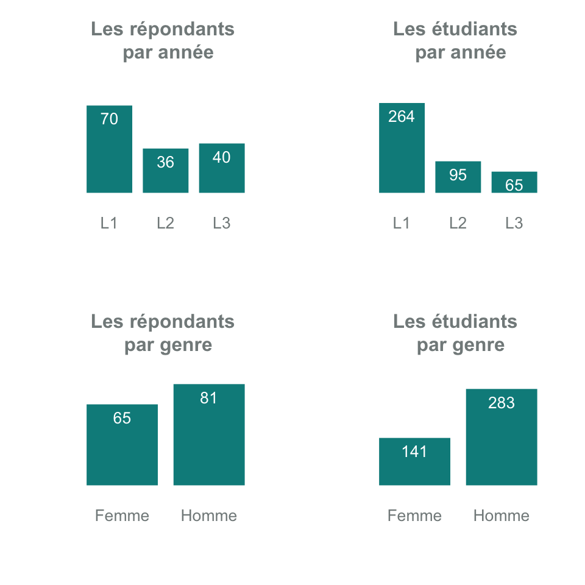

Nous pouvons constater que le taux de répondants des femmes est largement supérieur à celui des hommes en L1 et en L2 mais pas en L3. Nous devons prendre en compte que les hommes sont plus nombreux que les femmes en L1, en L2 et en L3 ce qui peut biaiser notre analyse. Néanmoins, nous pouvons conclure que les femmes sont plus investies que les hommes et que les dernières années sont plus investies que les premières années. Nous pensons intéressant de regarder l’investissement dans l’association A€T pour voir si les femmes sont plus investies que les hommes dans cette dernière mais nous n’avons pas choisi cet axe d’analyse.

# Les résultats :

Nous allons analyser dans un premier temps la motivation selon le genre et dans un second temps les moyennes selon le genre des étudiants de la licence d’Économie à Tours. Les hypothèses que nous avons choisi sont :

- Les femmes sont plus motivées que les hommes,
- Les femmes sont plus motivées que les hommes à augmenter leur moyenne entre le semestre 1 et le semestre 2,
- Les femmes ont une meilleure moyenne générale que les hommes,
- Les femmes ont de meilleures moyennes que les hommes dans les enseignements “littéraires” et à contrario les hommes ont de meilleures moyennes que les femmes dans les enseignements “scientifiques”.

Pour confirmer ou non nos hypothèses, nous allons analyser les variables `Genre`, `Motivation`, `Evo_note`, `Note`, `Macro`, `Micro`, `Maths`, `Stat` et `Anglais` de la base de données finale `data`. Nous interrogerons et testerons nos hypothèses en visualisant ces données dans des tableaux, des graphiques et en réalisant des tests.

## La *motivation* :

### Graphiques et tableaux :

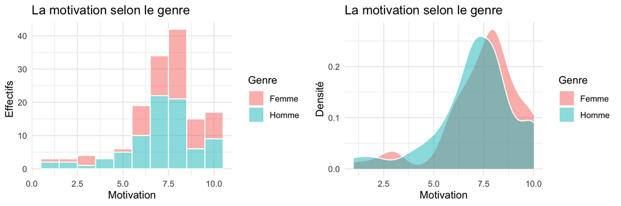

La motivation selon le genre :

| Motivation | Femme | Homme |
| --- | --- | --- |
| 1 | 1 | 2 |
| 2 | 1 | 2 |
| 3 | 3 | 1 |
| 4 | 0 | 3 |
| 5 | 1 | 5 |
| 6 | 9 | 10 |
| 7 | 12 | 22 |
| 8 | 21 | 21 |
| 9 | 9 | 6 |
| 10 | 8 | 9 |

La motivation moyenne chez les femmes est de 7.45 tandis que chez les hommes elle est de 7.06. La motivation médiane chez les femmes est de 8 tandis que chez les hommes elle est de 7. Les femmes sont moins nombreuses que les hommes à avoir une motivation en dessous de $\frac{5}{10}$. Nous en supposons donc que les femmes sont plus motivées que les hommes.

### Tests :

Nous allons tester si les femmes sont plus motivées que les hommes.

Le test d’appartenance :

|  | x |
| --- | --- |
| Motivation.p.value | 0 |

Le test de moyenne de la motivation selon le genre

|  | Femme | Homme | var.equal | mean in group Femme | mean in group Homme | p.value |
| --- | --- | --- | --- | --- | --- | --- |
| Motivation | 65 | 81 | Oui | 7.45 | 7.06 | 0.24 |

La p.value et l’effectif théorique mninimum du test d’indépendance :

|  | Motivation |
| --- | --- |
| Eff_théorique_min | 1.34 |
| p-value | 0.41 |

Nous constatons grâce au test d’appartenance que la `p.value` est inférieure au risque de première espèce : $\alpha = 0.05$. Avec un risque de 5 %, la motivation ne suit pas une loi normale.<sup>1</sup>

Les conclusions suivantes sont à relativiser.<sup>1,</sup> <sup>2</sup> Nous pouvons constater grâce au test des variances que ces dernières sont égales et nous constatons grâce au test bilatéral de Student que la `p.value` est supérieure au risque de première espèce : $\alpha = 0.05$. Nous en arrivons à la conclusion, avec un risque de 5%, que la motivation entre les femmes et les hommes n’est pas significativement différente.

<sup>1</sup> Nous avons supposé que la motivation suit une loi normale du fait que les effectifs soient petits.

<sup>2</sup> Les effectifs théoriques minimums sont inférieurs à 5 donc les conditions de validité ne sont pas remplies.

## L’évolution de la moyenne entre le *semestre 1* et le *semestre 2* (en pourcentage) :

### Graphiques et tableaux :

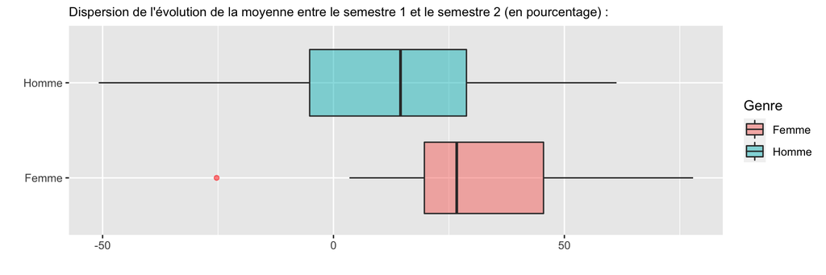

Le résumé de l’évolution de la moyenne entre le semestre 1 et le semestre 2 selon le genre (en pourcentage) :

|  | Moyenne | Ecart-type | Minimum | Q1 | Q2 | Q3 | Maximum |
| --- | --- | --- | --- | --- | --- | --- | --- |
| Evo_note_Femme | 29.88 | 22.34 | -25.31 | 20.59 | 26.54 | 38.13 | 77.87 |
| Evo_note_Homme | 9.83 | 29.51 | -50.84 | -6.93 | 11.31 | 24.91 | 61.29 |

Les femmes ont augmenté leur moyenne entre le semestre 1 et le semestre 2 de 29,88 % en moyenne tandis que les hommes ont augmenté leur moyenne entre le semestre 1 et le semestre 2 de 9,83 % en moyenne. Nous pouvons aussi constater une différence significative entre l’évolution minimum qui est de 25,31 % chez les femmes contre 50,84 % chez les hommes. Cela se voit également sur la boîte à moustahe, où l’on constate un écart majeur entre les femmes et les hommes. Nous en supposons donc que les femmes “rebondissent” ou tout du moins “s’adaptent” mieux que les hommes en première année de la licence d’Économie à Tours.

### Tests :

Nous allons tester si les femmes “rebondissent” mieux que les hommes en première année de la licence d’Économie à Tours.

La p.value du test d’appartenance :

|  | x |
| --- | --- |
| Evo_note.p.value | 0.39 |

Le test de moyenne de l’évolution de la moyenne entre le semestre 1 et le semestre 2 selon le genre

|  | Femme | Homme | var.equal | mean in group Femme | mean in group Homme | p.value |
| --- | --- | --- | --- | --- | --- | --- |
| Evo_note | 26 | 22 | Non | 29.88 | 9.83 | 0.01 |

La p.value et l’effectif théorique mninimum du test d’indépendance :

|  | Evo_note |
| --- | --- |
| Eff_théorique_min | 0.46 |
| p-value | 0.43 |

Nous constatons grâce au test d’appartenance que la `p.value` est supérieure au risque de première espèce : $\alpha = 0.05$. Avec un risque de 5 %, l’évolution de la moyenne entre le semestre 1 et 2 suit une loi normale.

Les conclusions suivantes sont à relativiser.<sup>1</sup> Nous pouvons constater grâce au test des variances que ces dernières ne sont pas égales et nous constatons grâce au test bilatéral de Student que la `p.value` est inférieure au risque de première espèce : $\alpha = 0.05$. Nous en arrivons à la conclusion, avec un risque de 5%, que l’évolution de la moyenne entre le semestre 1 et 2 est significativement différente entre les femmes et les hommes.

<sup>1</sup> Les effectifs théoriques minimums sont inférieurs à 5 donc les conditions de validité ne sont pas remplies.

**Nous allons regrouper des données :**

Nous transformons les femmes dont l’évolution de la moyenne entre le semestre 1 et le semestre 2 a diminué et nous leur donnons la valeur de -25.31 (moyenne) ainsi que les femmes dont l’évolution de la moyenne entre le semestre 1 et le semestre 2 a augmenté et nous leur donnons la valeur de 32.09 (moyenne). Nous appliquons les mêmes transformations aux hommes.

La p.value et l’effectif théorique mninimum du test d’indépendance :

|  | Evo_note |
| --- | --- |
| Eff_théorique_min | 0.46 |
| Chi 2 | 48.00 |
| p-value | 0.00 |

Les effectifs théoriques minimums sont inférieurs à 5 donc les conditions de validité ne sont toujours pas remplies.

Nous retransformons les femmes et nous leur donnons la valeur de 29.88 (moyenne). Nous appliquons la même transformation aux hommes.

La p.value et l’effectif théorique mninimum du test d’indépendance :

|  | Evo_note |
| --- | --- |
| Eff_théorique_min | 28.94 |
| Chi 2 | 141.98 |
| p-value | 0.00 |

Les effectifs théoriques minimums sont supérieurs à 5 donc les conditions de validité sont remplies. Nous constatons grâce au test d’indépendance que la `p.value` est inférieure au risque de première espèce : $\alpha = 0.05$. Avec un risque de 5 %, l’évolution de la moyenne entre le semestre 1 et 2 est dépendante du genre.

En conclusion, nous pouvons affirmer que l’évolution de la moyenne entre le semestre 1 et le semestre 2 d’un étudiant de la licence d’Économie à Tours dépend de son genre. Les femmes augmentent plus leur moyenne entre le semestre 1 et le semestre 2 que les hommes. Il peut être intéressant de voir si les femmes ont une moyenne moins élevée que les hommes au semestre 1 et plus élevée que les hommes au semestre 2 mais nous n’avons pas choisi cet axe d’analyse.

## La *moyenne générale* :

### Graphiques et tableau :

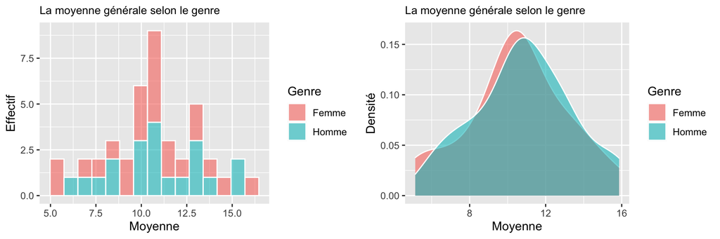

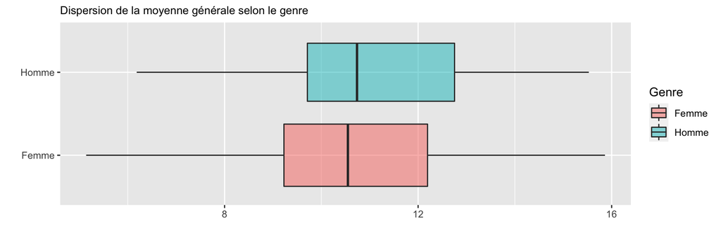

La moyenne générale selon le genre :

|  | $\|$ $x$ < 10 $\|$ 7.78 | $\|$ 10 < $x$ ≤ 12 $\|$ 10.87 | $\|$ 12 < $x$ ≤ 14 $\|$ 13.04 | $\|$ 14 < $x$ ≤ 16 $\|$ 15.34 |
| --- | --- | --- | --- | --- |
| Femme | 10 | 9 | 6 | 2 |
| Homme | 6 | 13 | 4 | 2 |

Nous pouvons constater une différence non-significative de la moyenne entre les femmes et les hommes. En effet, nous observons très légèrement que les femmes ont une moyenne générale moins élevée que les hommes. Nous pouvons supposer que les femmes réussissent moins que les hommes.

### Tests :

Nous allons tester si les femmes réussissent moins que les hommes.

La p.value du test d’appartenance :

|  | x |
| --- | --- |
| Note.p.value | 0.55 |

Le test de moyenne de la moyenne générale selon le genre

|  | Femme | Homme | var.equal | mean in group Femme | mean in group Homme | p.value |
| --- | --- | --- | --- | --- | --- | --- |
| Note | 27 | 25 | Oui | 10.62 | 10.74 | 0.87 |

La p.value et l’effectif théorique mninimum du test d’indépendance :

|  | Note |
| --- | --- |
| Eff_théorique_min | 0.48 |
| Chi 2 | 52.00 |
| p-value | 0.43 |

Nous constatons grâce au test d’appartenance que la `p.value` est supérieure au risque de première espèce : $\alpha = 0.05$. Avec un risque de 5 %, la moyenne générale suit une loi normale.

Les conclusions suivantes sont à relativiser.<sup>1</sup> Nous pouvons constater grâce au test des variances que ces dernières sont égales et nous constatons grâce au test bilatéral de Student que la `p.value` est supérieure au risque de première espèce : $\alpha = 0.05$. Nous en arrivons à la conclusion, avec un risque de 5 %, que la moyenne générale entre les femmes et les hommes n’est pas pas significativement différente.

<sup>1</sup> Les effectifs théoriques minimums sont inférieurs à 5 donc les conditions de validité ne sont pas remplies.

## Les *moyennes* des enseignements de *Macro*, de *Micro*, de *Maths*, de *Stat* et d’*Anglais* :

### Graphiques et tableaux :

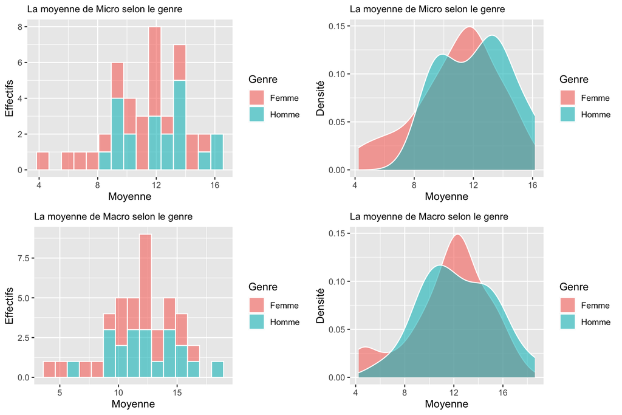

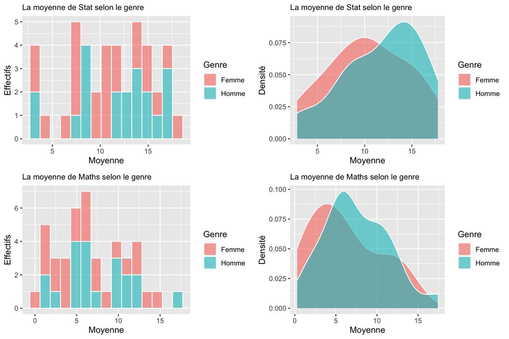

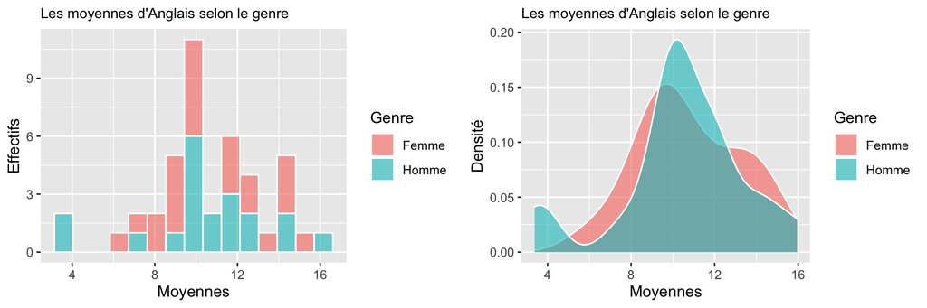

Le résumé des moyennes des enseignements pour les femmes :

|  | Moyenne | Ecart-type | Minimum | Q1 | Q2 | Q3 | Maximum |
| --- | --- | --- | --- | --- | --- | --- | --- |
| Macro | 11.57 | 3.38 | 4.25 | 9.75 | 12.10 | 13.57 | 17.13 |
| Micro | 10.68 | 2.88 | 4.25 | 9.05 | 11.05 | 12.25 | 15.70 |
| Maths | 5.93 | 4.28 | 0.00 | 2.15 | 5.40 | 8.88 | 14.40 |
| Stat | 10.34 | 4.48 | 2.44 | 7.38 | 10.45 | 14.32 | 17.75 |
| Anglais | 10.70 | 2.41 | 5.88 | 9.25 | 10.25 | 12.75 | 15.25 |

Le résumé des moyennes des enseignements pour les hommes :

[output not shown]

Nous pouvons constater qu’il n’y a pas de différence significative des moyennes entre les femmes et les hommes. En revanche, en Micro et en Stats, nous pouvons constater une différence non-significative entre les femmes et les hommes. La moyenne de Micro pour les femmes est de 10.68 tandis que pour les hommes elle est de 11.56, de même pour les Stats, les femmes ont une moyenne de 10.34 tandis que les hommes ont une moyenne de 11.19. La moyenne d’Anglais pour les femmes est de 10.7 (données eronnées enlevées) tandis que pour les hommes elle est de 10.26. Nous pouvons également confirmer cela par la densité. En effet, en Micro Et stat la densité se situe plus sur la droite pour les hommes que pour les femmes.Nous pouvons supposer que les femmes réussissent légèrement moins que les hommes dans les enseignements scientifiques mais légèrement mieux dans les enseignements littéraires.

### Tests :

Nous allons tester si femmes réussissent légèrement moins que les hommes dans les enseignements scientifiques et légèrement mieux dans les enseignements littéraires.

Le test d’appartenance :

|  | x |
| --- | --- |
| Macro.p.value | 0.74 |
| Micro.p.value | 0.37 |
| Maths.p.value | 0.02 |
| Stat.p.value | 0.08 |
| Anglais.p.value | 0.00 |

Le test de moyenne des moyennes des enseignements selon le genre

|  | Femme | Homme | var.equal | mean in group Femme | mean in group Homme | p.value |
| --- | --- | --- | --- | --- | --- | --- |
| Macro | 26 | 21 | Oui | 11.57 | 12.05 | 0.63 |
| Micro | 25 | 22 | Oui | 10.68 | 11.56 | 0.32 |
| Maths | 29 | 26 | Oui | 5.93 | 6.4 | 0.68 |
| Stat | 27 | 23 | Oui | 10.34 | 11.19 | 0.49 |
| Anglais | 29 | 29 | Oui | 11.8 | 10.26 | 0.25 |

La p.value et l’effectif théorique mninimum du test d’indépendance :

|  | Macro | Micro | Maths | Stat | Anglais |
| --- | --- | --- | --- | --- | --- |
| Eff_théorique_min | 0.45 | 0.47 | 0.47 | 0.46 | 0.50 |
| p-value | 0.39 | 0.24 | 0.56 | 0.43 | 0.42 |

Nous constatons grâce au test d’appartenance que les `p.values` sont supérieures pour la Macro, la Micro et les Stats et sont inférieures pour les Maths et l’Anglais au risque de première espèce : $\alpha = 0.05$. Avec un risque de 5 %, les moyennes de Macro, de Micro et de Stat suivent des lois normales et celles de Maths et d’Anglais ne suivent pas des lois normales.<sup>1</sup>

Les conclusions suivants sont à relativiser.^1, <sup>2</sup> Nous constatons grâce au test des variances que ces dernières sont égales et nous constatons grâce au test bilatéral de Student que les `p.values` sont supérieures au risque de première espèce : $\alpha = 0.05$. Nous concluons, avec un risque de 5 %, que les moyennes de Macro, de Micro, de Maths, de Stat et d’Anglais entre les femmes et les hommes ne sont pas sigificativement différentes.

<sup>1</sup> Nous avons supposé que les moyennes de Maths et d’Anglais suivent des lois normales du fait que les effectifs soient petits.

<sup>2</sup> Les effectifs théoriques minimums sont inférieurs à 5 donc les conditions de validité ne sont pas remplies.

# Les choix :

Nous allons analyser le choix du niveau d’éducation visé selon le genre pour les étudiants de la licence d’Économie à Tours. Les hypothèses que nous avons choisi sont :

- Les femmes veulent faire des études plus longues que les hommes.
- Les femmes et les hommes motivés veulent faire des études plus longues.

Pour confirmer ou non nos hypothèse, nous allons analyser les variables `Genre`, `Motivation` et `Niveau_edu_vise` de la base de données finale `data`. Nous interrogerons nos hypothèses en visualisant ces données dans des tableaux et des graphiques.

## *Le niveau d’éducation visé* :

### Graphique et tableau :

> **Cette analyse est descriptive.**

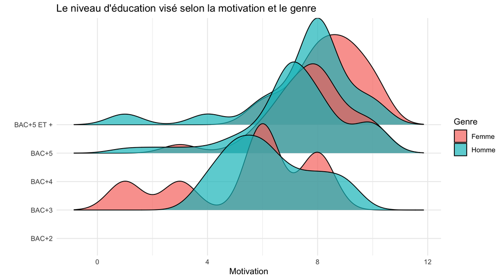

Le niveau d’éducation visé selon le genre :

|  | Femme | Homme |
| --- | --- | --- |
| BAC+2 | 1 | 1 |
| BAC+3 | 7 | 8 |
| BAC+4 | 0 | 1 |
| BAC+5 | 47 | 52 |
| BAC+5 ET + | 10 | 19 |

Nous pouvons constater une différence non-significative du niveau d’éducation visé entre les femmes et les hommes et une différence significative du niveau d’éducation visé selon la motivation. En effet, nous observons très légèrement que les femmes veulent faire des études moins longues que les hommes. En revanche, nous observons que plus les femmes et les hommes sont motivés et plus le niveau d’éducation visé est élevé.

En conclusion, nous pouvons supposer que le niveau d’éducation visé d’un étudiant de la licence d’Économie à Tours dépend davantage de sa motivation que de son genre.

# Conclusion :

Pour conclure, nous devons tout de même nuancer nos résultats puisque nous avons supposé que certaines variables suivaient des lois normales à contrario des résultats des tests d’appartenances et certains tests ne respectaient pas les conditions de validité.

Nous pouvons rejetter l’hypothèse que le genre va influencer les résultats. En effet, nous constatons que les femmes ont des résultats presque similaires aux hommes. En revanche, l’hypothèse qui est basée sur l’évolution entre la moyenne du semestre 1 et du semestre 2, est conservée. Les femmes vont mieux réussir leur semestre 2 par rapport au semestre 1 que les hommes.

Enfin, notre analyse descriptive sur le niveau d’éducation visé, nous “indique”, en l’abscence de tests, que le genre ne va pas avoir d’influence sur ce dernier mais qu’ici, cela dépend d’avantage de la motivation des étudiants.